# Coursera Data Science Specialisation - Predictive Modelling Course Project

agamzine

2023-06-26

## Executive Summary

Using devices such as Jawbone Up, Nike FuelBand, and Fitbit it is now possible to collect a large amount of data about personal activity relatively inexpensively. These type of devices are part of the quantified self movement: a group of enthusiasts who take measurements about themselves regularly to improve their health, to find patterns in their behavior, or because they are tech geeks. One thing that people regularly do is quantify how much of a particular activity they do, but they rarely quantify how well they do it.

The goal of this project is to predict the manner in which 6 participants performed an exercise, using data from accelerometers on the belt, forearm, arm, and dumbell as they performed barbell lifts correctly and incorrectly in 5 different ways.

## Data Processing

```r
training_raw <- read.csv("pml-training.csv")
testing_raw <- read.csv("pml-testing.csv")
```

In addition, the data can be broken up into the following buckets: - The target outcome (‘classe’) - how well the participants perform the activity - The entity descriptors (‘user’, ‘timestamp’) - The measurements taken from the accelerometers

## Feature Engineering

There are over 150 columns we can use for analysis, but this is likely to be too many to be manageable. To improve how well our model runs we should reduce the number of features using some techniques such as principal component analysis.

Lets begin by cleaning the data and removing columns with errors or missing data, for now lets assume that the model will perform well enough even without those columns:

```r
#Feature engineer training
to.remove <- c("classe")
training_clean <- training_raw[ , 7:160]
training_clean <- training_clean[ , -which(names(training_clean) %in% to.remove)]

training_clean <- data.frame(lapply(training_clean,as.numeric))
training_clean <- training_clean[ , colSums(is.na(training_clean))==0]


#Copy to testing
to.remove <- c("problem_id")
testing_clean <- testing_raw[ , 7:160]
testing_clean <- testing_clean[ , -which(names(testing_clean) %in% to.remove)]

testing_clean <- data.frame(lapply(testing_clean,as.numeric))
testing_clean <- testing_clean[ , colSums(is.na(testing_clean))==0]
```

We are left with just 56 variables to perform our PCA. Since the data are recording the physical movements of participants, you would expect to see a correlation between certain variables (as you move your body up using your legs, your belt moves up and so do your arms - for example). Lets see if these variables are correlated with one another to assess whether PCA will be beneficial to the models.

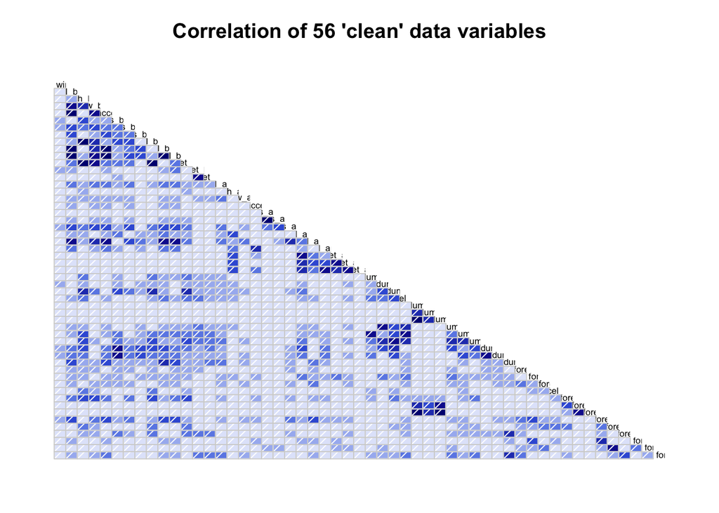

```r
library(corrgram)
M <- abs(cor(training_clean))

corrgram(M, order=NULL, lower.panel=panel.shade, upper.panel=NULL, text.panel=panel.txt, main="Correlation of 56 'clean' data variables")
```

Then we can run the prcomp function to perform the PCA:

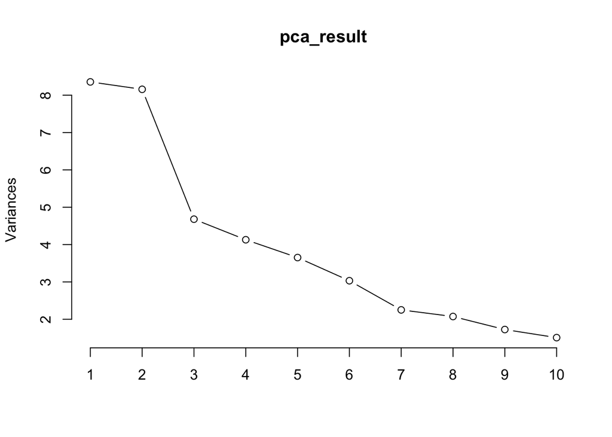

```r
pca_result <- prcomp(training_clean, center = TRUE, scale. = TRUE)
#pca_result <- prcomp(log10(training_clean+1))

# Plot the PCA results
plot(pca_result, type = "l")
```

## Prediction Modelling

Since this is a discrete classification problem, lets use a decision tree model - specifically random forest - to predict the classe in the testing dataset.

```r
#Load the caret package
library(caret)

#Principal component analysis for the training data
preProc <- preProcess(training_clean, method = "pca", pcaComp = 10)

#Find the PCA's for the training data
trainPC <- predict(preProc, training_clean)

#Add the actual values to the PCA dataframe
trainPC$classe <- as.factor(training_raw$classe)

#Train a random forest model
modelFit <- train(classe ~ ., method = "rf", data = trainPC)

#Use the same principal components on the testing data
testPC <- predict(preProc, testing_clean)

#Make the predictions on the testing data using the trained model
p <- predict(modelFit, testPC)

p
```

[output not shown]